# Analyzing Child HIV Prevalence Across Nine Different Countries of High HIV Prevalence

## DATS 6103 - Fall 2020 - Jesse Liu

#### Project Purpose:

- The purpose of the project is to analyze Child HIV prevalence data and compare it with that respective country's total healthcare spending per capita.
- The countries chosen presented the highest HIV prevalence in their respective regions: Africa, Asia, and South America. The countries analyzed are: Nigeria, Kenya, Ethiopia, Mozambique, Myanmar, Haiti, Pakistan, Philippines, and Venezuela.
- Children are defined as ages 0-14 years old in these analyzed datasets.

##### Presentation Outline:

1. Importing Data
2. Data Cleaning and Preprocessing
3. Data Visualization and Analysis
4. Conclusions

### 1. Importing Packages and Datasets

```python
#Importing Packages
import pandas as pd
import matplotlib.pyplot as plt
import numpy as np
from IPython.display import display
pd.options.display.float_format = '{:,.10f}'.format
```

```python
#Using Pandas to read in CSV Datasets
hiv_data = pd.read_csv('HIV_Epidemiology_Children_Adolescents_2020.csv', skiprows = 1)
hc_data = pd.read_csv('healthcaredata.csv', skiprows = 4)


#Citing Data Sources
from IPython.core.display import display, HTML
display(HTML("""<a href="https://data.unicef.org/topic/hivaids/global-regional-trends/">Key HIV epidemiology indicators for children and adolescents aged 0-19, 2000-2019</a>"""))

from IPython.core.display import display, HTML
display(HTML("""<a href="https://data.worldbank.org/indicator/SH.XPD.CHEX.PC.CD">Worldbank Healthcare Expenditure per Capita (Current US$) Dataset</a>"""))
```

[Key HIV epidemiology indicators for children and adolescents aged 0-19, 2000-2019](https://data.unicef.org/topic/hivaids/global-regional-trends/)

[Worldbank Healthcare Expenditure per Capita (Current US$) Dataset](https://data.worldbank.org/indicator/SH.XPD.CHEX.PC.CD)

### 2. Data Cleaning and Preprocessing

```python
#Filtering initial dataset to contain columns of interest
cols= ["Country/Region", "Indicator", "Year", "Sex", "Age", "Value"]
hiv_data = hiv_data[cols]
hiv_data = hiv_data.rename(columns={'Country/Region':'Country'})
hiv_data['Value']=hiv_data.Value.astype(str).astype(float)
```

```python
#Filtering initial dataset to contain columns of interest
hc_cols= ["Country","2010","2011","2012","2013","2014","2015","2016","2017"]
hc_data = hc_data[hc_cols]
hc_data = hc_data.loc[(hc_data.Country=="Nigeria")|(hc_data.Country=="Kenya")|(hc_data.Country=="Ethiopia")|(hc_data.Country=="Mozambique")|(hc_data.Country=="Venezuela")|(hc_data.Country=="Haiti")|(hc_data.Country=="Myanmar")|(hc_data.Country=="Pakistan")|(hc_data.Country=="Philippines")]
```

```python
#Formatting the data using set_index to use Country column as the dataframe index.
hc_data.set_index(["Country"], inplace = True)
hc_tdata= hc_data.transpose()
```

```python
#First dataframe for total annual deaths`
ad_global=hiv_data.loc[(hiv_data.Country=="Global")&(hiv_data.Indicator == "Estimated number of annual AIDS-related deaths")&((hiv_data.Year>=2010)&(hiv_data.Year <=2019))&(hiv_data.Sex=="Both")& (hiv_data.Age=="Age 0-14")]
#Creating Dataframe for 10 countries of interest using slicing via .loc function
annuald_data=hiv_data.loc[((hiv_data.Country=="Nigeria")|(hiv_data.Country=="Kenya")|(hiv_data.Country=="Ethiopia")|(hiv_data.Country=="Mozambique")|(hiv_data.Country=="Venezuela")|(hiv_data.Country=="Haiti")|(hiv_data.Country=="Democratic Republic of the Congo")|(hiv_data.Country=="Myanmar")|(hiv_data.Country=="Pakistan")|(hiv_data.Country=="Philippines"))&(hiv_data.Indicator == "Estimated number of annual AIDS-related deaths")&((hiv_data.Year>=2010)&(hiv_data.Year <=2017))&(hiv_data.Sex=="Both")& (hiv_data.Age=="Age 0-14")]
newannual_data=hiv_data.loc[((hiv_data.Country=="Nigeria")|(hiv_data.Country=="Kenya")|(hiv_data.Country=="Ethiopia")|(hiv_data.Country=="Mozambique")|(hiv_data.Country=="Venezuela")|(hiv_data.Country=="Haiti")|(hiv_data.Country=="Democratic Republic of the Congo")|(hiv_data.Country=="Myanmar")|(hiv_data.Country=="Pakistan")|(hiv_data.Country=="Philippines"))&(hiv_data.Indicator == "Estimated number of annual new HIV infections")&((hiv_data.Year>=2010)&(hiv_data.Year <=2017))&(hiv_data.Sex=="Both")& (hiv_data.Age=="Age 0-14")]
newannualrate_data=hiv_data.loc[((hiv_data.Country=="Nigeria")|(hiv_data.Country=="Kenya")|(hiv_data.Country=="Ethiopia")|(hiv_data.Country=="Mozambique")|(hiv_data.Country=="Venezuela")|(hiv_data.Country=="Haiti")|(hiv_data.Country=="Democratic Republic of the Congo")|(hiv_data.Country=="Myanmar")|(hiv_data.Country=="Pakistan")|(hiv_data.Country=="Philippines"))&(hiv_data.Indicator == "Estimated number of people living with HIV")&((hiv_data.Year>=2010)&(hiv_data.Year <=2017))&(hiv_data.Sex=="Both")& (hiv_data.Age=="Age 0-14")]
newannualinc_data=hiv_data.loc[((hiv_data.Country=="Nigeria")|(hiv_data.Country=="Kenya")|(hiv_data.Country=="Ethiopia")|(hiv_data.Country=="Mozambique")|(hiv_data.Country=="Venezuela")|(hiv_data.Country=="Haiti")|(hiv_data.Country=="Democratic Republic of the Congo")|(hiv_data.Country=="Myanmar")|(hiv_data.Country=="Pakistan")|(hiv_data.Country=="Philippines"))&(hiv_data.Indicator == "Estimated incidence rate (new HIV infection per 1000 uninfected population)")&((hiv_data.Year>=2010)&(hiv_data.Year <=2017))&(hiv_data.Sex=="Both")& (hiv_data.Age=="Age 0-14")]
```

```python
#Further specifying datasets to contain columns of interest: Country, Year, Value (the number or incidence of new HIV cases)
newannual_cols= ["Country", "Year", "Value"]
newannual_data = newannual_data[newannual_cols]
newannualrate_data = newannualrate_data[newannual_cols]
newannualinc_data = newannualinc_data[newannual_cols]
```

```python
#Creating annual new estimated deaths per country datasets to be concated
newannual_nig = newannual_data.loc[(newannual_data.Country=="Nigeria")]
newannual_keny = newannual_data.loc[(newannual_data.Country=="Kenya")]
newannual_eth = newannual_data.loc[(newannual_data.Country=="Ethiopia")]
newannual_moz = newannual_data.loc[(newannual_data.Country=="Mozambique")]
newannual_cog = newannual_data.loc[(newannual_data.Country=="Democratic Republic of the Congo")]
newannual_ven = newannual_data.loc[(newannual_data.Country=="Venezuela")]
newannual_myan = newannual_data.loc[(newannual_data.Country=="Myanmar")]
newannual_hait = newannual_data.loc[(newannual_data.Country=="Haiti")]
newannual_pak = newannual_data.loc[(newannual_data.Country=="Pakistan")]
newannual_phil = newannual_data.loc[(newannual_data.Country=="Philippines")]
```

```python
#Creating number of total people living with HIV per country datasets to be concated
newannualrate_nig = newannualrate_data.loc[(newannualrate_data.Country=="Nigeria")]
newannualrate_keny = newannualrate_data.loc[(newannualrate_data.Country=="Kenya")]
newannualrate_eth = newannualrate_data.loc[(newannualrate_data.Country=="Ethiopia")]
newannualrate_moz = newannualrate_data.loc[(newannualrate_data.Country=="Mozambique")]
newannualrate_cog = newannualrate_data.loc[(newannualrate_data.Country=="Democratic Republic of the Congo")]
newannualrate_ven = newannualrate_data.loc[(newannualrate_data.Country=="Venezuela")]
newannualrate_myan = newannualrate_data.loc[(newannualrate_data.Country=="Myanmar")]
newannualrate_hait = newannualrate_data.loc[(newannualrate_data.Country=="Haiti")]
newannualrate_pak = newannualrate_data.loc[(newannualrate_data.Country=="Pakistan")]
newannualrate_phil = newannualrate_data.loc[(newannualrate_data.Country=="Philippines")]
```

```python
#Creating annual new estimated incidence rate per country datasets to be concated
newannualinc_nig = newannualinc_data.loc[(newannualinc_data.Country=="Nigeria")]
newannualinc_keny = newannualinc_data.loc[(newannualinc_data.Country=="Kenya")]
newannualinc_eth = newannualinc_data.loc[(newannualinc_data.Country=="Ethiopia")]
newannualinc_moz = newannualinc_data.loc[(newannualinc_data.Country=="Mozambique")]
newannualinc_cog = newannualinc_data.loc[(newannualinc_data.Country=="Democratic Republic of the Congo")]
newannualinc_ven = newannualinc_data.loc[(newannualinc_data.Country=="Venezuela")]
newannualinc_myan = newannualinc_data.loc[(newannualinc_data.Country=="Myanmar")]
newannualinc_hait = newannualinc_data.loc[(newannualinc_data.Country=="Haiti")]
newannualinc_pak = newannualinc_data.loc[(newannualinc_data.Country=="Pakistan")]
newannualinc_phil = newannualinc_data.loc[(newannualinc_data.Country=="Philippines")]
```

### 3: Data Cleaning and Preprocessing: Reformatting

```python
#Creating years as indexes for new annual cases in perparation to be concated
newannual_nig.set_index(["Year"], inplace = True)
newannual_keny.set_index(["Year"], inplace = True)
newannual_eth.set_index(["Year"], inplace = True)
newannual_moz.set_index(["Year"], inplace = True)
newannual_cog.set_index(["Year"], inplace = True)
newannual_ven.set_index(["Year"], inplace = True)
newannual_myan.set_index(["Year"], inplace = True)
newannual_hait.set_index(["Year"], inplace = True)
newannual_pak.set_index(["Year"], inplace = True)
newannual_phil.set_index(["Year"], inplace = True)
```

```python
#Creating years as indexes for new annual cases
newannualrate_nig.set_index(["Year"], inplace = True)
newannualrate_keny.set_index(["Year"], inplace = True)
newannualrate_eth.set_index(["Year"], inplace = True)
newannualrate_moz.set_index(["Year"], inplace = True)
newannualrate_cog.set_index(["Year"], inplace = True)
newannualrate_ven.set_index(["Year"], inplace = True)
newannualrate_myan.set_index(["Year"], inplace = True)
newannualrate_hait.set_index(["Year"], inplace = True)
newannualrate_pak.set_index(["Year"], inplace = True)
newannualrate_phil.set_index(["Year"], inplace = True)
```

```python
#Creating years as indexes for new annual incidence rates cases
newannualinc_nig.set_index(["Year"], inplace = True)
newannualinc_keny.set_index(["Year"], inplace = True)
newannualinc_eth.set_index(["Year"], inplace = True)
newannualinc_moz.set_index(["Year"], inplace = True)
newannualinc_cog.set_index(["Year"], inplace = True)
newannualinc_ven.set_index(["Year"], inplace = True)
newannualinc_myan.set_index(["Year"], inplace = True)
newannualinc_hait.set_index(["Year"], inplace = True)
newannualinc_pak.set_index(["Year"], inplace = True)
newannualinc_phil.set_index(["Year"], inplace = True)
```

```python
#combining new annual deaths using years as same index

newannual_all = pd.concat([newannual_nig["Value"], newannual_keny["Value"], newannual_eth["Value"], newannual_moz["Value"],newannual_ven["Value"], newannual_myan["Value"], newannual_hait["Value"], newannual_pak["Value"], newannual_phil["Value"], newannual_cog["Value"]], axis =1, keys = ["Nigeria", "Kenya", "Ethiopia", "Mozambique", "Venezuela", "Myanmar", "Haiti", "Pakistan", "Philippines"])
newannualrate_all = pd.concat([newannualrate_nig["Value"], newannualrate_keny["Value"], newannualrate_eth["Value"], newannualrate_moz["Value"], newannualrate_ven["Value"], newannualrate_myan["Value"], newannualrate_hait["Value"], newannualrate_pak["Value"], newannualrate_phil["Value"]], axis =1, keys = ["Nigeria", "Kenya", "Ethiopia", "Mozambique", "Venezuela", "Myanmar", "Haiti", "Pakistan", "Philippines"])
newannualinc_all = pd.concat([newannualinc_nig["Value"], newannualinc_keny["Value"], newannualinc_eth["Value"], newannualinc_moz["Value"], newannualinc_ven["Value"], newannualinc_myan["Value"], newannualinc_hait["Value"], newannualinc_pak["Value"], newannualinc_phil["Value"]], axis =1, keys = ["Nigeria", "Kenya", "Ethiopia", "Mozambique", "Venezuela", "Myanmar", "Haiti", "Pakistan", "Philippines"])
```

```python
#Example of the the prepared dataset (new annual HIV cases in children 0-14 ages) used in the data visualizations
newannual_all
```

| Year | Nigeria | Kenya | Ethiopia | Mozambique | Venezuela | Myanmar | Haiti | Pakistan | Philippines |
| --- | --- | --- | --- | --- | --- | --- | --- | --- | --- |
| 2010 | 28,000.0000000000 | 18,000.0000000000 | 8,100.0000000000 | 30,000.0000000000 | 780.0000000000 | 1,500.0000000000 | 1,600.0000000000 | 780.0000000000 | 100.0000000000 |
| 2011 | 27,000.0000000000 | 14,000.0000000000 | 6,900.0000000000 | 25,000.0000000000 | 770.0000000000 | 1,400.0000000000 | 1,300.0000000000 | 850.0000000000 | 100.0000000000 |
| 2012 | 25,000.0000000000 | 16,000.0000000000 | 5,500.0000000000 | 20,000.0000000000 | 740.0000000000 | 1,500.0000000000 | 1,100.0000000000 | 940.0000000000 | 100.0000000000 |
| 2013 | 21,000.0000000000 | 15,000.0000000000 | 4,600.0000000000 | 19,000.0000000000 | 710.0000000000 | 1,500.0000000000 | 890.0000000000 | 1,000.0000000000 | 100.0000000000 |
| 2014 | 19,000.0000000000 | 13,000.0000000000 | 4,300.0000000000 | 18,000.0000000000 | 650.0000000000 | 1,300.0000000000 | 1,000.0000000000 | 1,100.0000000000 | 100.0000000000 |
| 2015 | 20,000.0000000000 | 9,200.0000000000 | 3,800.0000000000 | 17,000.0000000000 | 610.0000000000 | 1,200.0000000000 | 950.0000000000 | 1,200.0000000000 | 100.0000000000 |
| 2016 | 19,000.0000000000 | 8,500.0000000000 | 4,000.0000000000 | 18,000.0000000000 | 570.0000000000 | 1,100.0000000000 | 970.0000000000 | 1,300.0000000000 | 100.0000000000 |
| 2017 | 20,000.0000000000 | 9,000.0000000000 | 3,900.0000000000 | 16,000.0000000000 | 550.0000000000 | 1,000.0000000000 | 880.0000000000 | 1,300.0000000000 | 200.0000000000 |

## 3. Data Visualization and Analysis

### A) Overall Global Deaths in Children

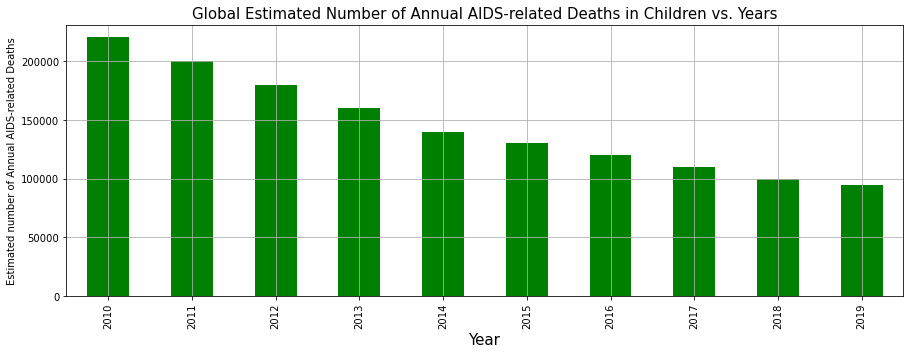

```python
#Creating Timeseries plot that compares total deaths from HIV in children ages 0-14 years old
ad_global.plot(x='Year', y="Value", kind="bar", color = "green",  legend =False, figsize = (15,5))
plt.xlabel("Year", fontsize = 15)
plt.ylabel("Estimated number of Annual AIDS-related Deaths", fontsize = 10)
plt.title("Global Estimated Number of Annual AIDS-related Deaths in Children vs. Years", fontsize = 15)
plt.grid(True)
```

### B) Comparison of Children Living with HIV-AIDS

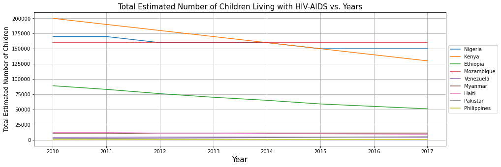

```python
#Creating Timeseries plot that compares total children living with HIV AIDS
newannualrate_all.plot.line(y=["Nigeria", "Kenya", "Ethiopia", "Mozambique", "Venezuela", "Myanmar", "Haiti", "Pakistan", "Philippines"], figsize = (15,5))
plt.xlabel("Year", fontsize = 15)
plt.ylabel("Total Estimated Number of Children", fontsize = 12)
plt.title("Total Estimated Number of Children Living with HIV-AIDS vs. Years", fontsize = 15)
plt.legend(loc='center left', bbox_to_anchor=(1, 0.5))
plt.grid(True)
```

Note: While total number of HIV deaths is decreasing, the total estimated number of children living with HIV-AIDS remains constant for most of the selected countries, with the exception of Kenya and Ethiopia.

### C) Comparison of Annual New HIV Infections in Children

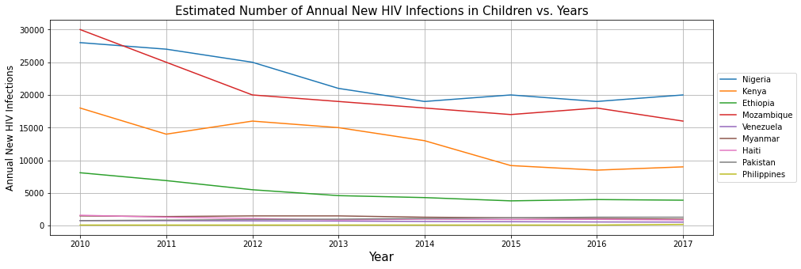

```python
#Creating Timeseries plot that compares new cases of children living with HIV AIDS
newannual_all.plot.line(y=["Nigeria", "Kenya", "Ethiopia", "Mozambique", "Venezuela", "Myanmar", "Haiti", "Pakistan", "Philippines"], figsize = (15,5))
plt.xlabel("Year", fontsize = 15)
plt.ylabel("Annual New HIV Infections", fontsize = 12 )
plt.title("Estimated Number of Annual New HIV Infections in Children vs. Years", fontsize =15)
plt.legend(loc='center left', bbox_to_anchor=(1, 0.5))
plt.grid(True)
```

### D) Comparison of Annual New HIV Infections in Children as a Rate

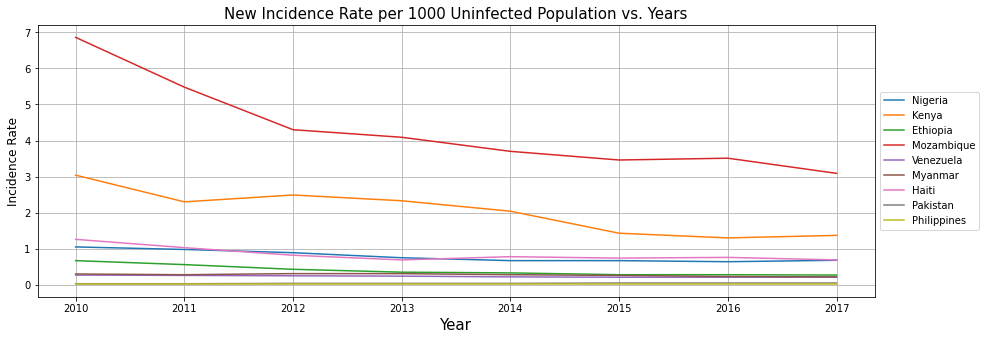

```python
#Creating Timeseries plot that compares new cases of children living with HIV AIDS as a rate
newannualinc_all.plot.line(y=["Nigeria", "Kenya", "Ethiopia", "Mozambique", "Venezuela", "Myanmar", "Haiti", "Pakistan", "Philippines"], figsize = (15,5))
plt.xlabel("Year", fontsize = 15)
plt.ylabel("Incidence Rate", fontsize =12)
plt.title("New Incidence Rate per 1000 Uninfected Population vs. Years", fontsize = 15)
plt.legend(loc='center left', bbox_to_anchor=(1, 0.5))
plt.grid(True)
```

### e) Comparison of Healthcare Spending per Capita

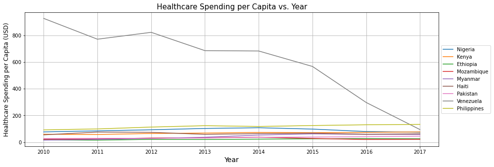

```python
#Creating Timeseries plot that compares total healthcare expenditure per capita
hc_tdata.plot.line(y=["Nigeria", "Kenya", "Ethiopia", "Mozambique", "Myanmar", "Haiti", "Pakistan", "Venezuela", "Philippines"], figsize = (15,5))
plt.xlabel("Year", fontsize=14)
plt.ylabel("Healthcare Spending per Capita (USD)", fontsize=12)
plt.title("Healthcare Spending per Capita vs. Year", fontsize = 15)
plt.legend(loc='center left', bbox_to_anchor=(1, 0.5))
plt.grid(True)
```

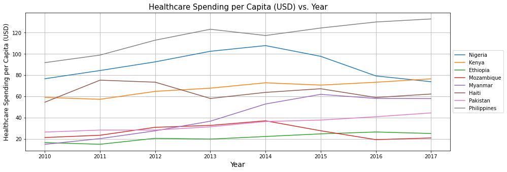

```python
#Creating Timeseries plot that compares total healthcare expenditure per capita, removing Venezuela
hc_tdata.plot.line(y=["Nigeria", "Kenya", "Ethiopia", "Mozambique", "Myanmar", "Haiti", "Pakistan", "Philippines"], figsize = (15,5))
plt.xlabel("Year", fontsize=14)
plt.ylabel("Healthcare Spending per Capita (USD)", fontsize=12)
plt.title("Healthcare Spending per Capita (USD) vs. Year", fontsize = 15)
plt.legend(loc='center left', bbox_to_anchor=(1, 0.5))
plt.grid(True)
```